# Assignment 1 - Exploratory Data Analysis

Author

Nathan Weitershausen

# Step 1

```r
 '2002_Data' <- read.csv("C:/Users/nweit/OneDrive/Desktop/PM566/Assignment 1 Data/2002 PM2.5 Data.csv")
dim(`2002_Data`)
```

```
[1] 15976    22
```

```r
head(`2002_Data`)
```

```
        Date Source  Site.ID POC Daily.Mean.PM2.5.Concentration    Units
1 01/05/2002    AQS 60010007   1                           25.1 ug/m3 LC
2 01/06/2002    AQS 60010007   1                           31.6 ug/m3 LC
3 01/08/2002    AQS 60010007   1                           21.4 ug/m3 LC
4 01/11/2002    AQS 60010007   1                           25.9 ug/m3 LC
5 01/14/2002    AQS 60010007   1                           34.5 ug/m3 LC
6 01/17/2002    AQS 60010007   1                           41.0 ug/m3 LC
  Daily.AQI.Value Local.Site.Name Daily.Obs.Count Percent.Complete
1              81       Livermore               1              100
2              93       Livermore               1              100
3              74       Livermore               1              100
4              82       Livermore               1              100
5              98       Livermore               1              100
6             115       Livermore               1              100
  AQS.Parameter.Code AQS.Parameter.Description Method.Code
```

[output cut: 27 more lines]

```r
tail(`2002_Data`)
```

```
            Date Source  Site.ID POC Daily.Mean.PM2.5.Concentration    Units
15971 12/10/2002    AQS 61131003   1                             15 ug/m3 LC
15972 12/13/2002    AQS 61131003   1                             15 ug/m3 LC
15973 12/22/2002    AQS 61131003   1                              1 ug/m3 LC
15974 12/25/2002    AQS 61131003   1                             23 ug/m3 LC
15975 12/28/2002    AQS 61131003   1                              5 ug/m3 LC
15976 12/31/2002    AQS 61131003   1                              6 ug/m3 LC
      Daily.AQI.Value      Local.Site.Name Daily.Obs.Count Percent.Complete
15971              62 Woodland-Gibson Road               1              100
15972              62 Woodland-Gibson Road               1              100
15973               6 Woodland-Gibson Road               1              100
15974              77 Woodland-Gibson Road               1              100
15975              28 Woodland-Gibson Road               1              100
15976              33 Woodland-Gibson Road               1              100
      AQS.Parameter.Code AQS.Parameter.Description Method.Code
```

[output cut: 27 more lines]

```r
str(`2002_Data`)
```

```
'data.frame':   15976 obs. of  22 variables:
 $ Date                          : chr  "01/05/2002" "01/06/2002" "01/08/2002" "01/11/2002" ...
 $ Source                        : chr  "AQS" "AQS" "AQS" "AQS" ...
 $ Site.ID                       : int  60010007 60010007 60010007 60010007 60010007 60010007 60010007 60010007 60010007 60010007 ...
 $ POC                           : int  1 1 1 1 1 1 1 1 1 1 ...
 $ Daily.Mean.PM2.5.Concentration: num  25.1 31.6 21.4 25.9 34.5 41 29.3 15 18.8 37.9 ...
 $ Units                         : chr  "ug/m3 LC" "ug/m3 LC" "ug/m3 LC" "ug/m3 LC" ...
 $ Daily.AQI.Value               : int  81 93 74 82 98 115 89 62 69 107 ...
 $ Local.Site.Name               : chr  "Livermore" "Livermore" "Livermore" "Livermore" ...
 $ Daily.Obs.Count               : int  1 1 1 1 1 1 1 1 1 1 ...
 $ Percent.Complete              : num  100 100 100 100 100 100 100 100 100 100 ...
 $ AQS.Parameter.Code            : int  88101 88101 88101 88101 88101 88101 88101 88101 88101 88101 ...
 $ AQS.Parameter.Description     : chr  "PM2.5 - Local Conditions" "PM2.5 - Local Conditions" "PM2.5 - Local Conditions" "PM2.5 - Local Conditions" ...
 $ Method.Code                   : int  120 120 120 120 120 120 120 120 120 120 ...
 $ Method.Description            : chr  "Andersen RAAS2.5-300 PM2.5 SEQ w/WINS" "Andersen RAAS2.5-300 PM2.5 SEQ w/WINS" "Andersen RAAS2.5-300 PM2.5 SEQ w/WINS" "Andersen RAAS2.5-300 PM2.5 SEQ w/WINS" ...
 $ CBSA.Code                     : int  41860 41860 41860 41860 41860 41860 41860 41860 41860 41860 ...
 $ CBSA.Name                     : chr  "San Francisco-Oakland-Hayward, CA" "San Francisco-Oakland-Hayward, CA" "San Francisco-Oakland-Hayward, CA" "San Francisco-Oakland-Hayward, CA" ...
 $ State.FIPS.Code               : int  6 6 6 6 6 6 6 6 6 6 ...
 $ State                         : chr  "California" "California" "California" "California" ...
 $ County.FIPS.Code              : int  1 1 1 1 1 1 1 1 1 1 ...
 $ County                        : chr  "Alameda" "Alameda" "Alameda" "Alameda" ...
 $ Site.Latitude                 : num  37.7 37.7 37.7 37.7 37.7 ...
 $ Site.Longitude                : num  -122 -122 -122 -122 -122 ...
```

```r
summary(`2002_Data`)
```

```
        Date             Source         Site.ID              POC
 Length   :15976   Length   :15976   Min.   :60010007   Min.   :1.000
 N.unique :  365   N.unique :    1   1st Qu.:60290014   1st Qu.:1.000
 N.blank  :    0   N.blank  :    0   Median :60590007   Median :1.000
 Min.nchar:   10   Min.nchar:    3   Mean   :60549600   Mean   :1.581
 Max.nchar:   10   Max.nchar:    3   3rd Qu.:60731002   3rd Qu.:1.000
                                     Max.   :61131003   Max.   :6.000

 Daily.Mean.PM2.5.Concentration       Units       Daily.AQI.Value
 Min.   :  0.00                 Length   :15976   Min.   :  0.00
 1st Qu.:  7.00                 N.unique :    1   1st Qu.: 39.00
 Median : 12.00                 N.blank  :    0   Median : 56.00
 Mean   : 16.12                 Min.nchar:    8   Mean   : 59.28
 3rd Qu.: 20.50                 Max.nchar:    8   3rd Qu.: 72.00
 Max.   :104.30                                   Max.   :185.00

  Local.Site.Name  Daily.Obs.Count Percent.Complete AQS.Parameter.Code
 Length   :15976   Min.   :1       Min.   :100      Min.   :88101
 N.unique :  103   1st Qu.:1       1st Qu.:100      1st Qu.:88101
 N.blank  :  118   Median :1       Median :100      Median :88101
 Min.nchar:    0   Mean   :1       Mean   :100      Mean   :88215
 Max.nchar:   43   3rd Qu.:1       3rd Qu.:100      3rd Qu.:88502
                   Max.   :1       Max.   :100      Max.   :88502

 AQS.Parameter.Description  Method.Code  Method.Description   CBSA.Code
 Length   :15976           Min.   :117   Length   :15976    Min.   :12540
 N.unique :    2           1st Qu.:120   N.unique :    6    1st Qu.:23420
 N.blank  :    0           Median :120   N.blank  :    0    Median :40140
 Min.nchar:   24           Mean   :297   Min.nchar:   28    Mean   :33270
 Max.nchar:   38           3rd Qu.:707   Max.nchar:   62    3rd Qu.:41740
                           Max.   :810                      Max.   :49700
                                                            NAs    :929
     CBSA.Name     State.FIPS.Code       State       County.FIPS.Code
 Length   :15976   Min.   :6       Length   :15976   Min.   :  1.00
 N.unique :   31   1st Qu.:6       N.unique :    1   1st Qu.: 29.00
 N.blank  :  929   Median :6       N.blank  :    0   Median : 59.00
 Min.nchar:    0   Mean   :6       Min.nchar:   10   Mean   : 54.78
 Max.nchar:   45   3rd Qu.:6       Max.nchar:   10   3rd Qu.: 73.00
                   Max.   :6                         Max.   :113.00

       County      Site.Latitude   Site.Longitude
 Length   :15976   Min.   :32.63   Min.   :-124.2
 N.unique :   48   1st Qu.:34.07   1st Qu.:-121.4
 N.blank  :    0   Median :35.36   Median :-119.1
 Min.nchar:    4   Mean   :36.00   Mean   :-119.4
 Max.nchar:   15   3rd Qu.:37.77   3rd Qu.:-117.9
                   Max.   :41.71   Max.   :-115.5
```

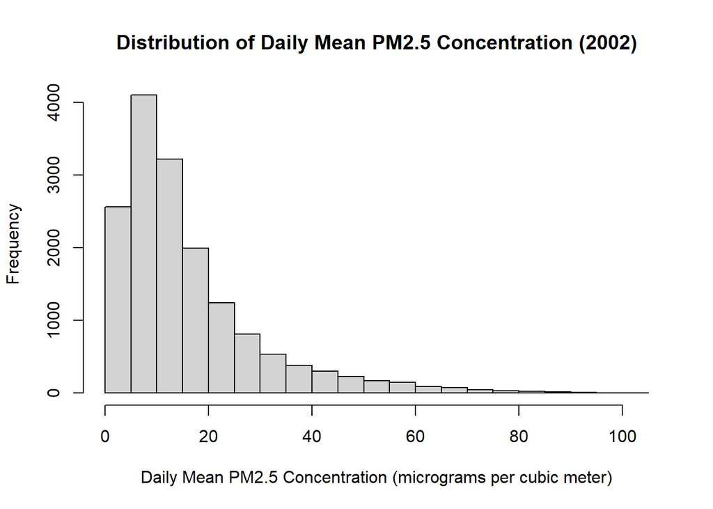

```r
'2002-DMPMC' <- `2002_Data`$Daily.Mean.PM2.5.Concentration
hist(`2002-DMPMC`, main = "Distribution of Daily Mean PM2.5 Concentration (2002)", xlab = "Daily Mean PM2.5 Concentration (micrograms per cubic meter)")
```

```r
'2022_Data' <- read.csv("C:/Users/nweit/OneDrive/Desktop/PM566/Assignment 1 Data/2022 PM2.5 Data.csv")
dim(`2022_Data`)
```

```
[1] 59918    22
```

```r
head(`2022_Data`)
```

```
        Date Source  Site.ID POC Daily.Mean.PM2.5.Concentration    Units
1 01/01/2022    AQS 60010007   3                           12.7 ug/m3 LC
2 01/02/2022    AQS 60010007   3                           13.9 ug/m3 LC
3 01/03/2022    AQS 60010007   3                            7.1 ug/m3 LC
4 01/04/2022    AQS 60010007   3                            3.7 ug/m3 LC
5 01/05/2022    AQS 60010007   3                            4.2 ug/m3 LC
6 01/06/2022    AQS 60010007   3                            3.8 ug/m3 LC
  Daily.AQI.Value Local.Site.Name Daily.Obs.Count Percent.Complete
1              58       Livermore               1              100
2              60       Livermore               1              100
3              39       Livermore               1              100
4              21       Livermore               1              100
5              23       Livermore               1              100
6              21       Livermore               1              100
  AQS.Parameter.Code AQS.Parameter.Description Method.Code
```

[output cut: 27 more lines]

```r
tail(`2022_Data`)
```

```
            Date Source  Site.ID POC Daily.Mean.PM2.5.Concentration    Units
59913 12/01/2022    AQS 61131003   1                            3.4 ug/m3 LC
59914 12/07/2022    AQS 61131003   1                            3.8 ug/m3 LC
59915 12/13/2022    AQS 61131003   1                            6.0 ug/m3 LC
59916 12/19/2022    AQS 61131003   1                           34.8 ug/m3 LC
59917 12/25/2022    AQS 61131003   1                           23.2 ug/m3 LC
59918 12/31/2022    AQS 61131003   1                            1.0 ug/m3 LC
      Daily.AQI.Value      Local.Site.Name Daily.Obs.Count Percent.Complete
59913              19 Woodland-Gibson Road               1              100
59914              21 Woodland-Gibson Road               1              100
59915              33 Woodland-Gibson Road               1              100
59916              99 Woodland-Gibson Road               1              100
59917              77 Woodland-Gibson Road               1              100
59918               6 Woodland-Gibson Road               1              100
      AQS.Parameter.Code AQS.Parameter.Description Method.Code
```

[output cut: 27 more lines]

```r
str(`2022_Data`)
```

```
'data.frame':   59918 obs. of  22 variables:
 $ Date                          : chr  "01/01/2022" "01/02/2022" "01/03/2022" "01/04/2022" ...
 $ Source                        : chr  "AQS" "AQS" "AQS" "AQS" ...
 $ Site.ID                       : int  60010007 60010007 60010007 60010007 60010007 60010007 60010007 60010007 60010007 60010007 ...
 $ POC                           : int  3 3 3 3 3 3 3 3 3 3 ...
 $ Daily.Mean.PM2.5.Concentration: num  12.7 13.9 7.1 3.7 4.2 3.8 2.3 6.9 13.6 11.2 ...
 $ Units                         : chr  "ug/m3 LC" "ug/m3 LC" "ug/m3 LC" "ug/m3 LC" ...
 $ Daily.AQI.Value               : int  58 60 39 21 23 21 13 38 59 55 ...
 $ Local.Site.Name               : chr  "Livermore" "Livermore" "Livermore" "Livermore" ...
 $ Daily.Obs.Count               : int  1 1 1 1 1 1 1 1 1 1 ...
 $ Percent.Complete              : num  100 100 100 100 100 100 100 100 100 100 ...
 $ AQS.Parameter.Code            : int  88101 88101 88101 88101 88101 88101 88101 88101 88101 88101 ...
 $ AQS.Parameter.Description     : chr  "PM2.5 - Local Conditions" "PM2.5 - Local Conditions" "PM2.5 - Local Conditions" "PM2.5 - Local Conditions" ...
 $ Method.Code                   : int  170 170 170 170 170 170 170 170 170 170 ...
 $ Method.Description            : chr  "Met One BAM-1020 Mass Monitor w/VSCC" "Met One BAM-1020 Mass Monitor w/VSCC" "Met One BAM-1020 Mass Monitor w/VSCC" "Met One BAM-1020 Mass Monitor w/VSCC" ...
 $ CBSA.Code                     : int  41860 41860 41860 41860 41860 41860 41860 41860 41860 41860 ...
 $ CBSA.Name                     : chr  "San Francisco-Oakland-Hayward, CA" "San Francisco-Oakland-Hayward, CA" "San Francisco-Oakland-Hayward, CA" "San Francisco-Oakland-Hayward, CA" ...
 $ State.FIPS.Code               : int  6 6 6 6 6 6 6 6 6 6 ...
 $ State                         : chr  "California" "California" "California" "California" ...
 $ County.FIPS.Code              : int  1 1 1 1 1 1 1 1 1 1 ...
 $ County                        : chr  "Alameda" "Alameda" "Alameda" "Alameda" ...
 $ Site.Latitude                 : num  37.7 37.7 37.7 37.7 37.7 ...
 $ Site.Longitude                : num  -122 -122 -122 -122 -122 ...
```

```r
summary(`2022_Data`)
```

```
        Date             Source         Site.ID              POC
 Length   :59918   Length   :59918   Min.   :60010007   Min.   : 1.000
 N.unique :  365   N.unique :    1   1st Qu.:60290019   1st Qu.: 1.000
 N.blank  :    0   N.blank  :    0   Median :60631006   Median : 3.000
 Min.nchar:   10   Min.nchar:    3   Mean   :60564225   Mean   : 3.768
 Max.nchar:   10   Max.nchar:    3   3rd Qu.:60731026   3rd Qu.: 3.000
                                     Max.   :61131003   Max.   :24.000

 Daily.Mean.PM2.5.Concentration       Units       Daily.AQI.Value
 Min.   : -6.700                Length   :59918   Min.   :  0.00
 1st Qu.:  4.100                N.unique :    1   1st Qu.: 23.00
 Median :  6.800                N.blank  :    0   Median : 38.00
 Mean   :  8.414                Min.nchar:    8   Mean   : 39.22
 3rd Qu.: 10.700                Max.nchar:    8   3rd Qu.: 54.00
 Max.   :302.500                                  Max.   :454.00

  Local.Site.Name  Daily.Obs.Count Percent.Complete AQS.Parameter.Code
 Length   :59918   Min.   :1       Min.   :100      Min.   :88101
 N.unique :  165   1st Qu.:1       1st Qu.:100      1st Qu.:88101
 N.blank  :    0   Median :1       Median :100      Median :88101
 Min.nchar:    3   Mean   :1       Mean   :100      Mean   :88196
 Max.nchar:   42   3rd Qu.:1       3rd Qu.:100      3rd Qu.:88101
                   Max.   :1       Max.   :100      Max.   :88502

 AQS.Parameter.Description  Method.Code    Method.Description   CBSA.Code
 Length   :59918           Min.   :143.0   Length   :59918    Min.   :12540
 N.unique :    2           1st Qu.:170.0   N.unique :   17    1st Qu.:31080
 N.blank  :    0           Median :170.0   N.blank  :    0    Median :40140
 Min.nchar:   24           Mean   :340.9   Min.nchar:   24    Mean   :34971
 Max.nchar:   38           3rd Qu.:731.0   Max.nchar:   62    3rd Qu.:41860
                           Max.   :810.0                      Max.   :49700
                                                              NAs    :4569
     CBSA.Name     State.FIPS.Code       State       County.FIPS.Code
 Length   :59918   Min.   :6       Length   :59918   Min.   :  1.00
 N.unique :   33   1st Qu.:6       N.unique :    1   1st Qu.: 29.00
 N.blank  : 4569   Median :6       N.blank  :    0   Median : 63.00
 Min.nchar:    0   Mean   :6       Min.nchar:   10   Mean   : 56.28
 Max.nchar:   45   3rd Qu.:6       Max.nchar:   10   3rd Qu.: 73.00
                   Max.   :6                         Max.   :113.00

       County      Site.Latitude   Site.Longitude
 Length   :59918   Min.   :32.58   Min.   :-124.2
 N.unique :   50   1st Qu.:34.07   1st Qu.:-121.4
 N.blank  :    0   Median :36.49   Median :-119.6
 Min.nchar:    4   Mean   :36.25   Mean   :-119.6
 Max.nchar:   15   3rd Qu.:37.96   3rd Qu.:-117.9
                   Max.   :41.76   Max.   :-115.5
```

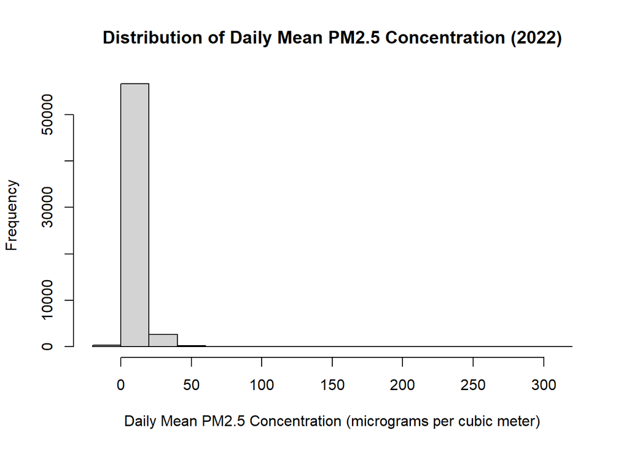

```r
'2022-DMPMC' <- `2022_Data`$Daily.Mean.PM2.5.Concentration
hist(`2022-DMPMC`, main = "Distribution of Daily Mean PM2.5 Concentration (2022)", xlab = "Daily Mean PM2.5 Concentration (micrograms per cubic meter)")
```

## Summary

While both datasets contain 22 variables, the 2002 dataset contains 15,976 observations and the 2022 dataset contains 59,918 observations. In 2002, the daily mean PM2.5 Concentration has a range of 0 to 104.3. In 2022, the daily mean PM2.5 Concentration has a range of -6.7 to 302.5, which may suggest an recording error, as PM2.5 Concentration values cannot be negative. The distributions of daily mean PM2.5 concentration between the two datasets are extremely different. According to the histograms and table views, in 2002, the majority of observations (4,101 or 25.7% of observations) lie within the 5-10 micrograms per cubic meter range, with a smooth drop off as concentration increases. In 2022, almost all observations (56,593 or 94.5% of observations) lie within the 0-20 micrograms per cubic meter range, with just a couple observations near 300 micrograms per cubic meter, and 343 observations lying in the -20 - 0 micrograms per cubic meter range. Both distributions are positively skewed, but it should be noted that the 2002 distribution ranges from 0 - 100 micrograms per cubic meter and the 2022 distribution ranges from -20 - 300 micrograms per cubic meter (before dataset cleaning).

# Step 2

```r
Combined_Data <- merge(`2002_Data`, `2022_Data`, all = TRUE)

Combined_Data$Date <- as.Date(Combined_Data$Date, format = "%m/%d/%Y")
Combined_Data$Year <- format(Combined_Data$Date, "%Y")

names(Combined_Data)[names(Combined_Data) == "Daily.Mean.PM2.5.Concentration"] <- "PM2.5"

head(Combined_Data)
```

```
        Date Source  Site.ID POC PM2.5    Units Daily.AQI.Value
1 2002-01-01    AQS 60074001   3  10.6 ug/m3 LC              54
2 2002-01-01    AQS 60130002   1  20.9 ug/m3 LC              73
3 2002-01-01    AQS 60290014   1  26.1 ug/m3 LC              83
4 2002-01-01    AQS 60290014   3  30.3 ug/m3 LC              90
5 2002-01-01    AQS 60290014   4  31.1 ug/m3 LC              92
6 2002-01-01    AQS 60370002   1  32.3 ug/m3 LC              94
            Local.Site.Name Daily.Obs.Count Percent.Complete AQS.Parameter.Code
1 TRAFFIC, RURAL PAVED ROAD               1              100              88502
2                   Concord               1              100              88101
3    Bakersfield-California               1              100              88101
4    Bakersfield-California               1              100              88502
5    Bakersfield-California               1              100              88502
6                     Azusa               1              100              88101
               AQS.Parameter.Description Method.Code
```

[output cut: 27 more lines]

```r
tail(Combined_Data)
```

```
            Date Source  Site.ID POC PM2.5    Units Daily.AQI.Value
75889 2022-12-31    AQS 61111004   3   0.1 ug/m3 LC               1
75890 2022-12-31    AQS 61112002   3   1.0 ug/m3 LC               6
75891 2022-12-31    AQS 61112002   4   1.5 ug/m3 LC               8
75892 2022-12-31    AQS 61113001   3   0.7 ug/m3 LC               4
75893 2022-12-31    AQS 61130004   3   2.0 ug/m3 LC              11
75894 2022-12-31    AQS 61131003   1   1.0 ug/m3 LC               6
                 Local.Site.Name Daily.Obs.Count Percent.Complete
75889       Ojai - East Ojai Ave               1              100
75890 Simi Valley-Cochran Street               1              100
75891 Simi Valley-Cochran Street               1              100
75892  El Rio-Rio Mesa School #2               1              100
75893           Davis-UCD Campus               1              100
75894       Woodland-Gibson Road               1              100
      AQS.Parameter.Code              AQS.Parameter.Description Method.Code
```

[output cut: 27 more lines]

```r
summary(Combined_Data)
```

```
      Date                  Source         Site.ID              POC
 Min.   :2002-01-01   Length   :75894   Min.   :60010007   Min.   : 1.000
 1st Qu.:2022-01-19   N.unique :    1   1st Qu.:60290018   1st Qu.: 1.000
 Median :2022-05-14   N.blank  :    0   Median :60631006   Median : 3.000
 Mean   :2018-04-16   Min.nchar:    3   Mean   :60561146   Mean   : 3.308
 3rd Qu.:2022-09-09   Max.nchar:    3   3rd Qu.:60731026   3rd Qu.: 3.000
 Max.   :2022-12-31                     Max.   :61131003   Max.   :24.000

     PM2.5              Units       Daily.AQI.Value   Local.Site.Name
 Min.   : -6.70   Length   :75894   Min.   :  0.00   Length   :75894
 1st Qu.:  4.40   N.unique :    1   1st Qu.: 24.00   N.unique :  199
 Median :  7.60   N.blank  :    0   Median : 42.00   N.blank  :  118
 Mean   : 10.04   Min.nchar:    8   Mean   : 43.45   Min.nchar:    0
 3rd Qu.: 12.20   Max.nchar:    8   3rd Qu.: 57.00   Max.nchar:   43
 Max.   :302.50                     Max.   :454.00

 Daily.Obs.Count Percent.Complete AQS.Parameter.Code AQS.Parameter.Description
 Min.   :1       Min.   :100      Min.   :88101      Length   :75894
 1st Qu.:1       1st Qu.:100      1st Qu.:88101      N.unique :    2
 Median :1       Median :100      Median :88101      N.blank  :    0
 Mean   :1       Mean   :100      Mean   :88200      Min.nchar:   24
 3rd Qu.:1       3rd Qu.:100      3rd Qu.:88101      Max.nchar:   38
 Max.   :1       Max.   :100      Max.   :88502

  Method.Code    Method.Description   CBSA.Code         CBSA.Name
 Min.   :117.0   Length   :75894    Min.   :12540   Length   :75894
 1st Qu.:170.0   N.unique :   20    1st Qu.:31080   N.unique :   33
 Median :170.0   N.blank  :    0    Median :40140   N.blank  : 5498
 Mean   :331.7   Min.nchar:   24    Mean   :34607   Min.nchar:    0
 3rd Qu.:707.0   Max.nchar:   62    3rd Qu.:41740   Max.nchar:   45
 Max.   :810.0                      Max.   :49700
                                    NAs    :5498
 State.FIPS.Code       State       County.FIPS.Code       County
 Min.   :6       Length   :75894   Min.   :  1.00   Length   :75894
 1st Qu.:6       N.unique :    1   1st Qu.: 29.00   N.unique :   51
 Median :6       N.blank  :    0   Median : 63.00   N.blank  :    0
 Mean   :6       Min.nchar:   10   Mean   : 55.96   Min.nchar:    4
 3rd Qu.:6       Max.nchar:   10   3rd Qu.: 73.00   Max.nchar:   15
 Max.   :6                         Max.   :113.00

 Site.Latitude   Site.Longitude          Year
 Min.   :32.58   Min.   :-124.2   Length   :75894
 1st Qu.:34.07   1st Qu.:-121.4   N.unique :    2
 Median :36.48   Median :-119.3   N.blank  :    0
 Mean   :36.20   Mean   :-119.5   Min.nchar:    4
 3rd Qu.:37.96   3rd Qu.:-117.9   Max.nchar:    4
 Max.   :41.76   Max.   :-115.5
```

# Step 3

```r
library(leaflet)

pal <- colorFactor(palette = c("blue", "red"), domain = Combined_Data$Year)

leaflet(Combined_Data) |>
  addTiles() |>
  addCircleMarkers(lng = Combined_Data$Site.Longitude, lat = Combined_Data$Site.Latitude, color = ~pal(Combined_Data$Year), radius = 5, stroke = TRUE, weight = 0.5, fillOpacity = 0.3) |>
  addLegend(position = "bottomleft", pal = pal, values = Combined_Data$Year, title = "Year", opacity = 1)
```

[interactive chart not shown]

## Summary

Based on the map, it appears that the distribution has expanded from 2002 to 2022. Some sites overlap, meaning that they exist in both years, but there are considerably more 2022 sites (red) than 2002 sites (blue). The “hotspots” appear to be Southern California, the Bay Area, and the Sacramento Area, while Northern California and Mojave are sparsely populated with sites.

# Step 4

```r
summary(Combined_Data)
```

```
      Date                  Source         Site.ID              POC
 Min.   :2002-01-01   Length   :75894   Min.   :60010007   Min.   : 1.000
 1st Qu.:2022-01-19   N.unique :    1   1st Qu.:60290018   1st Qu.: 1.000
 Median :2022-05-14   N.blank  :    0   Median :60631006   Median : 3.000
 Mean   :2018-04-16   Min.nchar:    3   Mean   :60561146   Mean   : 3.308
 3rd Qu.:2022-09-09   Max.nchar:    3   3rd Qu.:60731026   3rd Qu.: 3.000
 Max.   :2022-12-31                     Max.   :61131003   Max.   :24.000

     PM2.5              Units       Daily.AQI.Value   Local.Site.Name
 Min.   : -6.70   Length   :75894   Min.   :  0.00   Length   :75894
 1st Qu.:  4.40   N.unique :    1   1st Qu.: 24.00   N.unique :  199
 Median :  7.60   N.blank  :    0   Median : 42.00   N.blank  :  118
 Mean   : 10.04   Min.nchar:    8   Mean   : 43.45   Min.nchar:    0
 3rd Qu.: 12.20   Max.nchar:    8   3rd Qu.: 57.00   Max.nchar:   43
 Max.   :302.50                     Max.   :454.00

 Daily.Obs.Count Percent.Complete AQS.Parameter.Code AQS.Parameter.Description
 Min.   :1       Min.   :100      Min.   :88101      Length   :75894
 1st Qu.:1       1st Qu.:100      1st Qu.:88101      N.unique :    2
 Median :1       Median :100      Median :88101      N.blank  :    0
 Mean   :1       Mean   :100      Mean   :88200      Min.nchar:   24
 3rd Qu.:1       3rd Qu.:100      3rd Qu.:88101      Max.nchar:   38
 Max.   :1       Max.   :100      Max.   :88502

  Method.Code    Method.Description   CBSA.Code         CBSA.Name
 Min.   :117.0   Length   :75894    Min.   :12540   Length   :75894
 1st Qu.:170.0   N.unique :   20    1st Qu.:31080   N.unique :   33
 Median :170.0   N.blank  :    0    Median :40140   N.blank  : 5498
 Mean   :331.7   Min.nchar:   24    Mean   :34607   Min.nchar:    0
 3rd Qu.:707.0   Max.nchar:   62    3rd Qu.:41740   Max.nchar:   45
 Max.   :810.0                      Max.   :49700
                                    NAs    :5498
 State.FIPS.Code       State       County.FIPS.Code       County
 Min.   :6       Length   :75894   Min.   :  1.00   Length   :75894
 1st Qu.:6       N.unique :    1   1st Qu.: 29.00   N.unique :   51
 Median :6       N.blank  :    0   Median : 63.00   N.blank  :    0
 Mean   :6       Min.nchar:   10   Mean   : 55.96   Min.nchar:    4
 3rd Qu.:6       Max.nchar:   10   3rd Qu.: 73.00   Max.nchar:   15
 Max.   :6                         Max.   :113.00

 Site.Latitude   Site.Longitude          Year
 Min.   :32.58   Min.   :-124.2   Length   :75894
 1st Qu.:34.07   1st Qu.:-121.4   N.unique :    2
 Median :36.48   Median :-119.3   N.blank  :    0
 Mean   :36.20   Mean   :-119.5   Min.nchar:    4
 3rd Qu.:37.96   3rd Qu.:-117.9   Max.nchar:    4
 Max.   :41.76   Max.   :-115.5
```

```r
colSums(is.na(Combined_Data))
```

```
                     Date                    Source                   Site.ID
                        0                         0                         0
                      POC                     PM2.5                     Units
                        0                         0                         0
          Daily.AQI.Value           Local.Site.Name           Daily.Obs.Count
                        0                         0                         0
         Percent.Complete        AQS.Parameter.Code AQS.Parameter.Description
                        0                         0                         0
              Method.Code        Method.Description                 CBSA.Code
                        0                         0                      5498
                CBSA.Name           State.FIPS.Code                     State
                        0                         0                         0
         County.FIPS.Code                    County             Site.Latitude
                        0                         0                         0
           Site.Longitude                      Year
                        0                         0
```

```r
colMeans(is.na(Combined_Data))
```

```
                     Date                    Source                   Site.ID
               0.00000000                0.00000000                0.00000000
                      POC                     PM2.5                     Units
               0.00000000                0.00000000                0.00000000
          Daily.AQI.Value           Local.Site.Name           Daily.Obs.Count
               0.00000000                0.00000000                0.00000000
         Percent.Complete        AQS.Parameter.Code AQS.Parameter.Description
               0.00000000                0.00000000                0.00000000
              Method.Code        Method.Description                 CBSA.Code
               0.00000000                0.00000000                0.07244314
                CBSA.Name           State.FIPS.Code                     State
               0.00000000                0.00000000                0.00000000
         County.FIPS.Code                    County             Site.Latitude
               0.00000000                0.00000000                0.00000000
           Site.Longitude                      Year
               0.00000000                0.00000000
```

```r
Combined_Data[Combined_Data == 999999] <- NA
Combined_Data[Combined_Data == ""] <- NA

colSums(Combined_Data < 0)
```

```
                     Date                    Source                   Site.ID
                        0                         0                         0
                      POC                     PM2.5                     Units
                        0                       215                         0
          Daily.AQI.Value           Local.Site.Name           Daily.Obs.Count
                        0                        NA                         0
         Percent.Complete        AQS.Parameter.Code AQS.Parameter.Description
                        0                         0                         0
              Method.Code        Method.Description                 CBSA.Code
                        0                         0                        NA
                CBSA.Name           State.FIPS.Code                     State
                       NA                         0                         0
         County.FIPS.Code                    County             Site.Latitude
                        0                         0                         0
           Site.Longitude                      Year
                    75894                         0
```

```r
sum(Combined_Data$PM2.5 < 0, na.rm = TRUE)
```

```
[1] 215
```

```r
mean(Combined_Data$PM2.5 < 0, na.rm = TRUE)
```

```
[1] 0.002832899
```

```r
Implausible_Value <- is.na(Combined_Data$PM2.5) |
  Combined_Data$PM2.5 < 0
sum(Implausible_Value)
```

```
[1] 215
```

```r
mean(Implausible_Value)
```

```
[1] 0.002832899
```

```r
Proportion_2002 <- mean(Implausible_Value[Combined_Data$Year == 2002])
Proportion_2022 <- mean(Implausible_Value[Combined_Data$Year == 2022])

data.frame(Year = c(2002, 2022), Percent_Negative = c(Proportion_2002, Proportion_2022))
```

```
  Year Percent_Negative
1 2002      0.000000000
2 2022      0.003588237
```

## Summary

When looking for missing values (N/A values), I found that the CBSA.Code and CBSA.Name columns had 5,498 instances (~7.2% of observations), the Local.Site.Name column had 118 instances (~0.2% of observations), and all other variables had 0 instances. When looking at implausible values for the main variable, PM2.5, I found that 215 observations were below 0 (~0.3 observations). I determined that any values below 0 were implausible because mass concentration cannot be negative. So, the minimum pssoible PM2.5 concentration is 0 micrograms per cubic meter. I did not classify those extremely high PM2.5 as implausible, as the concentration may rise to such levels in wildfires. The proportion of these implausible values differs between 2002 and 2022, with the former having 0 implausible values and the latter having ~0.36% of observations being implausible.

# Step 5

Main Question: Did daily concentrations of PM2.5 decreased in California over the 20 years spanning from 2002 to 2022?

## Level 1: State

```r
Summary_Data <- data.frame(Year = as.numeric(as.character(Combined_Data$Year)), County = Combined_Data$County, Site = Combined_Data$Local.Site.Name, PM2.5 = as.numeric(as.character(Combined_Data$PM2.5)))

Summary_Data <- Summary_Data[!is.na(Summary_Data$PM2.5) & !is.na(Summary_Data$County) & !is.na(Summary_Data$Site) & !is.na(Summary_Data$Year) & Summary_Data$PM2.5 >= 0,]

State_Data <- Summary_Data[]

by(State_Data$PM2.5, State_Data$Year, summary)
```

```
State_Data$Year: 2002
   Min. 1st Qu.  Median    Mean 3rd Qu.    Max.
   0.00    7.00   12.00   16.06   20.40  104.30
------------------------------------------------------------
State_Data$Year: 2022
   Min. 1st Qu.  Median    Mean 3rd Qu.    Max.
  0.000   4.100   6.800   8.447  10.700 302.500
```

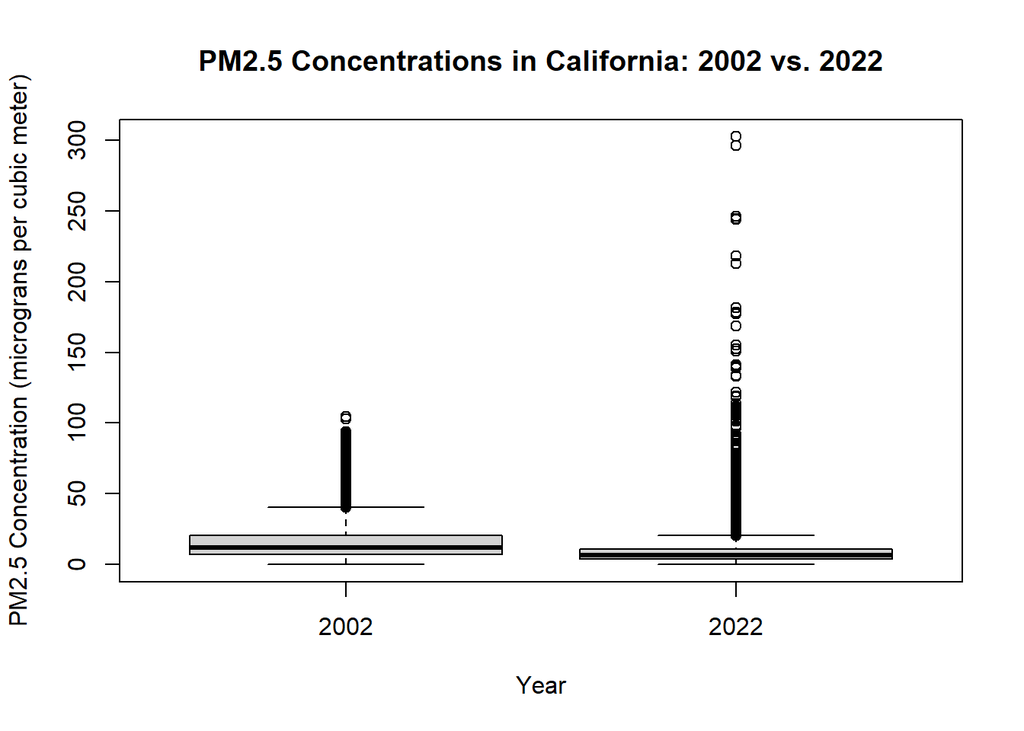

```r
boxplot(PM2.5 ~ Year, data = State_Data, main = "PM2.5 Concentrations in California: 2002 vs. 2022", ylab = "PM2.5 Concentration (micrograns per cubic meter)")
```

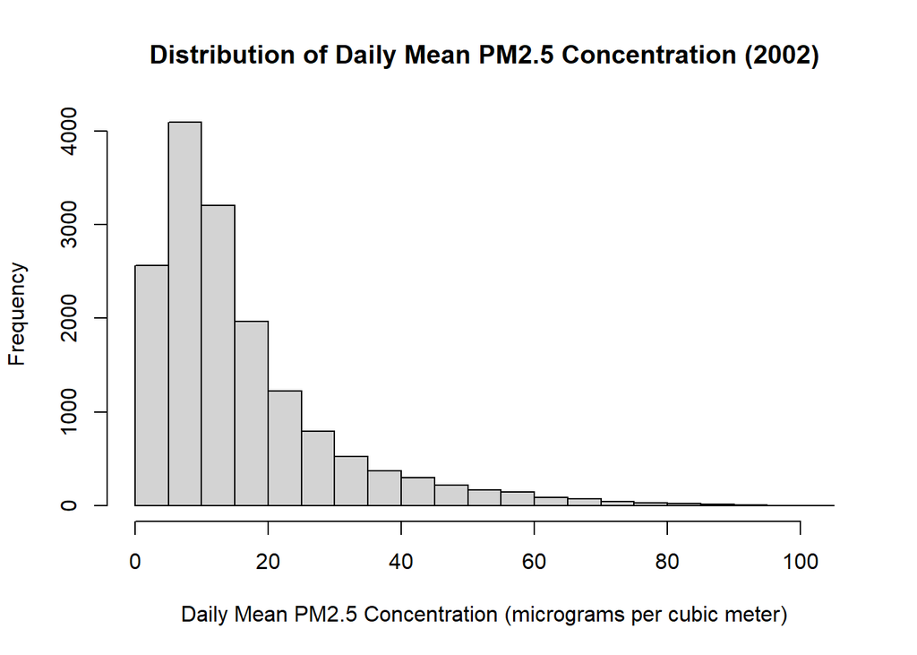

```r
PM2.5_2002 <- State_Data$PM2.5[State_Data$Year == 2002]
PM2.5_2022 <- State_Data$PM2.5[State_Data$Year == 2022]
hist(PM2.5_2002, main = "Distribution of Daily Mean PM2.5 Concentration (2002)", xlab = "Daily Mean PM2.5 Concentration (micrograms per cubic meter)")
```

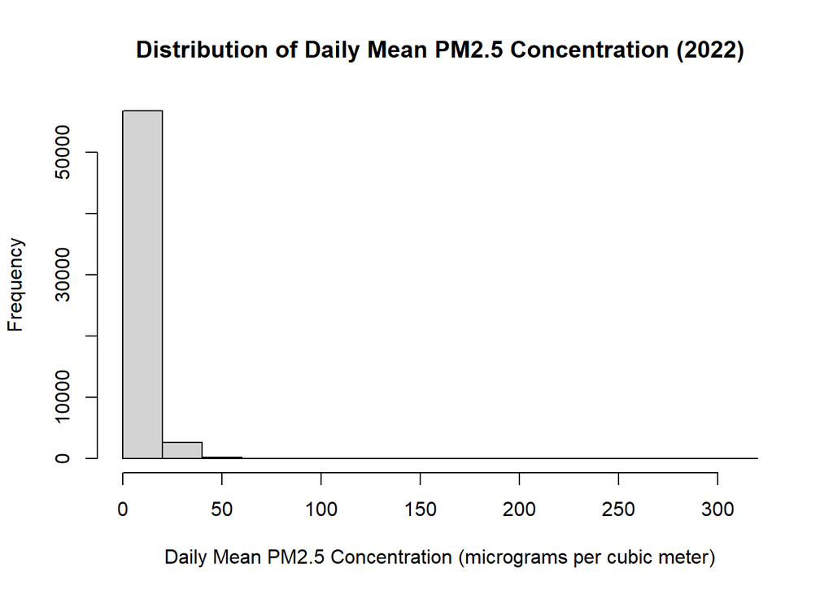

```r
hist(PM2.5_2022, main = "Distribution of Daily Mean PM2.5 Concentration (2022)", xlab = "Daily Mean PM2.5 Concentration (micrograms per cubic meter)")
```

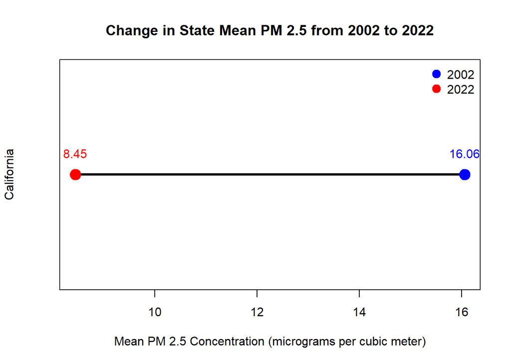

```r
Year2002 <- 2002
Year2022 <- 2022

State_Data <- subset(State_Data, Year %in% c(Year2002, Year2022) & !is.na(State_Data$PM2.5))

State_Means <- aggregate(PM2.5 ~ Year, data = State_Data, FUN = mean)

Mean_2002 <- State_Means$PM2.5[State_Means$Year == Year2002]
Mean_2022 <- State_Means$PM2.5[State_Means$Year == Year2022]

plot(NA, xlim = range(c(Mean_2002, Mean_2022)), ylim = c(0.5, 1.5), yaxt = "n", xlab = "Mean PM 2.5 Concentration (micrograms per cubic meter)", ylab = "California", main = paste("Change in State Mean PM 2.5 from 2002 to 2022"))

segments(x0 = Mean_2002, y0 = 1, x1 = Mean_2022, y1 = 1, lwd = 3)

points(Mean_2002, 1, pch = 19, col = "blue", cex = 2)

points(Mean_2022, 1, pch = 19, col = "red", cex = 2)

text( Mean_2002, 1.1, labels = round(Mean_2002, 2), col = "blue")

text(Mean_2022, 1.1, labels = round(Mean_2022, 2),col = "red")

legend( "topright", legend = c(Year2002, Year2022), col = c("blue", "red"), pch = 19, pt.cex = 1.5, bty = "n")
```

### Summary

At the state level, daily PM2.5 concentrations decreased in California between 2002 and 2022. THe mean concentration dropped from 16.06 micrograms per cubic meter in 2002 to 8.45 micrograms per cubic meter in 2022. The median concentration dropped from 12.00 micrograms per cubic meter in 2002 to 6.80 micrograms per cubic meter in 2022. Along with that, the distribution of concentrations in 2022 is more concentrated at lower values than the distribution of concentrations in 2002. However, the maximum concentration increased from 104.30 micrograms per cubic meter in 2002 to 302.50 micrograms per cubic meter in 2022. Though, the boxplot indicates that this 2022 maximum is an extreme outlier. Overall, daily PM2.5 concentrations have decreased in the 20-year period.

## Level 2: County

```r
County_Data <- Summary_Data[!is.na(Summary_Data$PM2.5) &!is.na(Summary_Data$County) & Summary_Data$PM2.5 >= 0,]

County_Means <- aggregate(PM2.5 ~ County + Year,data = County_Data,FUN = mean)

County_Means
```

```
            County Year     PM2.5
1          Alameda 2002 14.252736
2            Butte 2002 14.761311
3        Calaveras 2002  9.900000
4           Colusa 2002 11.726316
5     Contra Costa 2002 15.087319
6        Del Norte 2002  3.815455
7        El Dorado 2002  4.914423
8           Fresno 2002 19.929605
9         Humboldt 2002  7.794915
10        Imperial 2002 12.709649
11            Inyo 2002  7.141516
12            Kern 2002 23.001222
13           Kings 2002 24.695181
14            Lake 2002  6.503279
```

[output cut: 84 more lines]

```r
by(Summary_Data$PM2.5, list(County = Summary_Data$County,Year = Summary_Data$Year), summary)
```

```
County: Alameda
Year: 2002
   Min. 1st Qu.  Median    Mean 3rd Qu.    Max.
   1.90    6.70   10.00   14.25   16.90   61.60
------------------------------------------------------------
County: Butte
Year: 2002
   Min. 1st Qu.  Median    Mean 3rd Qu.    Max.
   1.00    7.30   11.50   14.76   17.80   88.00
------------------------------------------------------------
County: Calaveras
Year: 2002
   Min. 1st Qu.  Median    Mean 3rd Qu.    Max.
   2.00    6.00    8.00    9.90   12.25   40.00
------------------------------------------------------------
County: Colusa
Year: 2002
   Min. 1st Qu.  Median    Mean 3rd Qu.    Max.
   1.00    5.00    9.00   11.73   14.50   57.00
------------------------------------------------------------
County: Contra Costa
Year: 2002
   Min. 1st Qu.  Median    Mean 3rd Qu.    Max.
   2.00    6.50    9.50   15.09   16.62   76.70
------------------------------------------------------------
County: Del Norte
Year: 2002
   Min. 1st Qu.  Median    Mean 3rd Qu.    Max.
  0.000   1.900   3.450   3.815   5.650  12.300
------------------------------------------------------------
County: El Dorado
Year: 2002
   Min. 1st Qu.  Median    Mean 3rd Qu.    Max.
  0.100   2.000   3.950   4.914   7.000  27.000
------------------------------------------------------------
County: Fresno
Year: 2002
   Min. 1st Qu.  Median    Mean 3rd Qu.    Max.
   0.10    7.50   12.95   19.93   24.00   92.50
------------------------------------------------------------
```

[output cut: 450 more lines]

```
------------------------------------------------------------
County: Tulare
Year: 2022
   Min. 1st Qu.  Median    Mean 3rd Qu.    Max.
   0.00    5.90    8.70   10.51   12.70   48.30
------------------------------------------------------------
County: Ventura
Year: 2022
   Min. 1st Qu.  Median    Mean 3rd Qu.    Max.
  0.000   3.900   6.500   6.894   9.300  22.700
------------------------------------------------------------
County: Yolo
Year: 2022
   Min. 1st Qu.  Median    Mean 3rd Qu.    Max.
  0.000   2.025   3.900   5.547   7.200  34.800
```

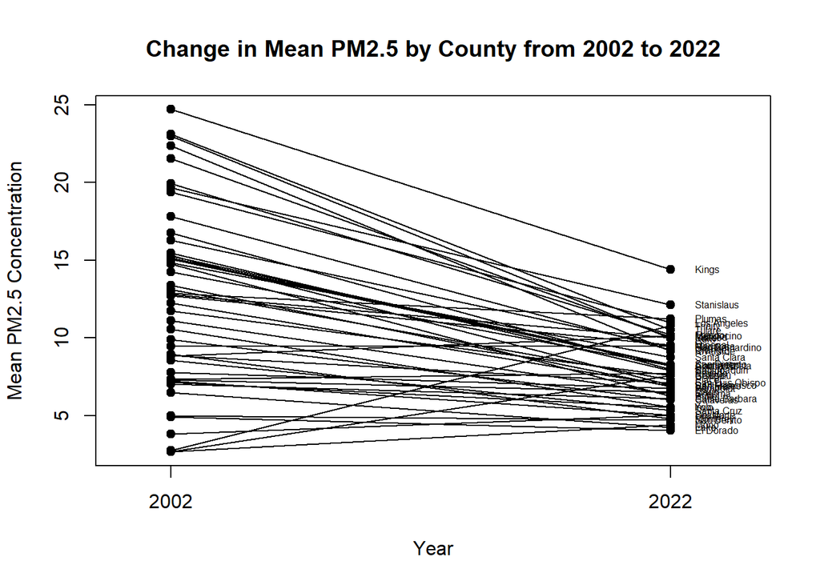

```r
plot(NA, xlim = c(2000, 2025), ylim = range(County_Means$PM2.5, na.rm = TRUE), xaxt = "n", xlab = "Year", ylab = "Mean PM2.5 Concentration", main = "Change in Mean PM2.5 by County from 2002 to 2022")

axis(side = 1, at = c(2002, 2022), labels = c("2002", "2022"))

County_List <- unique(County_Means$County)

for (County_Name in County_List) {
County_Values <- County_Means[County_Means$County == County_Name,]
if (
    2002 %in% County_Values$Year &&
    2022 %in% County_Values$Year
  ) {

    County_Values <- County_Values[order(County_Values$Year),]

    lines(County_Values$Year, County_Values$PM2.5, type = "o", pch = 19)

    text(x = 2022.5, y = County_Values$PM2.5[County_Values$Year == 2022], labels = County_Name, pos = 4, cex = 0.5)
  }
}
```

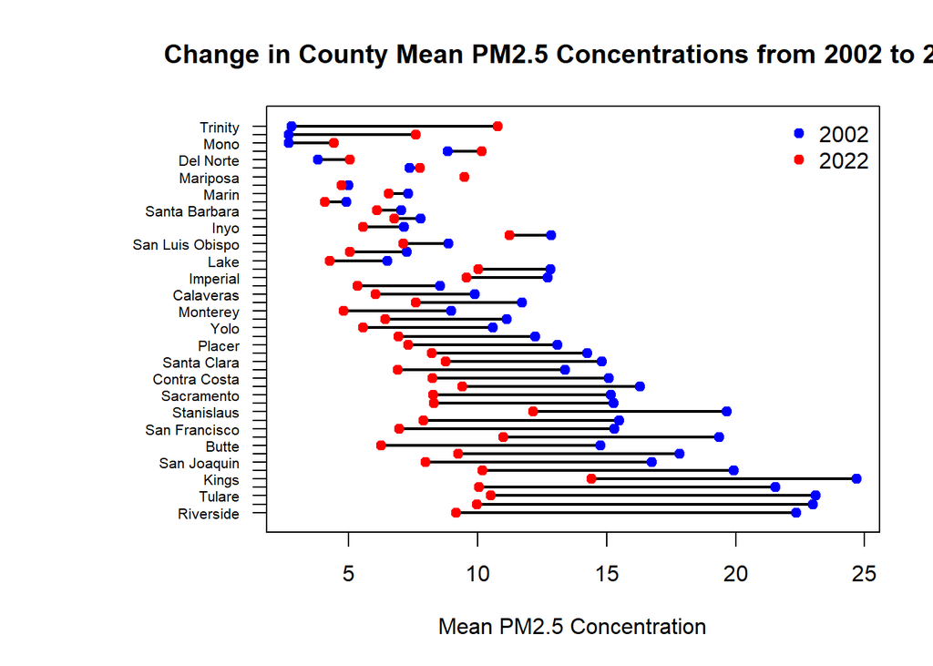

```r
Means_2002 <- County_Means[County_Means$Year == 2002, c("County", "PM2.5")]

Means_2022 <- County_Means[County_Means$Year == 2022, c("County", "PM2.5")]

names(Means_2002)[2] <- "Mean_2002"
names(Means_2022)[2] <- "Mean_2022"

County_Comparison <- merge(Means_2002, Means_2022, by = "County")

County_Comparison$Change <- County_Comparison$Mean_2022 - County_Comparison$Mean_2002

County_Comparison <- County_Comparison[order(County_Comparison$Change),]

plot_positions <- seq_len(nrow(County_Comparison))

par(mar = c(5, 10, 4, 2))

plot(NA, xlim = range(County_Comparison$Mean_2002, County_Comparison$Mean_2022), ylim = c(0.5, nrow(County_Comparison) + 0.5), yaxt = "n", xlab = "Mean PM2.5 Concentration", ylab = "", main = "Change in County Mean PM2.5 Concentrations from 2002 to 2022")

axis(side = 2, at = plot_positions, labels = County_Comparison$County, las = 1, cex.axis = 0.65)

segments(x0 = County_Comparison$Mean_2002, y0 = plot_positions, x1 = County_Comparison$Mean_2022, y1 = plot_positions, lwd = 2)

points(County_Comparison$Mean_2002, plot_positions, pch = 19, col = "blue")

points(County_Comparison$Mean_2022, plot_positions, pch = 19, col = "red")

legend( "topright", legend = c("2002", "2022"), col = c("blue", "red"), pch = 19, bty = "n")
```

## Summary

Based on the plots, it appears that the mean PM2.5 concentrations have decreased from 2002 to 2022 in most counties. The dumbbell plot reveals that six counties had an increase in mean PM2.5 concentrations between 2002 and 2022. Most counties had lower mean concentrations in 2022, with several counties experiencing large reductions in mean PM2.5 concentration since 2002. Overall, at the county level, PM2.5 concentrations generally decreased between 2002 and 2022, with only a few exceptions.

## Level 3: City

```r
unique(
  Summary_Data$County[grepl("Los Angeles", Summary_Data$County, ignore.case = TRUE)])
```

```
[1] "Los Angeles"
```

```r
LA_Data <- Summary_Data[Summary_Data$County == "Los Angeles" & Summary_Data$Year %in% c(2002, 2022) & !is.na(Summary_Data$Site) & !is.na(Summary_Data$PM2.5) & trimws(as.character(Summary_Data$Site)) != "" & Summary_Data$PM2.5 >= 0,]

LA_Data <- droplevels(LA_Data)

unique(LA_Data$Site)
```

```
 [1] "Azusa"                          "Los Angeles-North Main Street"
 [3] "Long Beach (North)"             "Glendora"
 [5] "Reseda"                         "Compton"
 [7] "Long Beach (South)"             "Long Beach-Route 710 Near Road"
 [9] "North Hollywood (NOHO)"         "Santa Clarita"
[11] "Lancaster-Division Street"      "Burbank"
[13] "Lynwood"                        "Pasadena"
[15] "Lebec"                          "Pico Rivera #2"
[17] "Signal Hill (LBSH)"
```

```r
table(LA_Data$Site, LA_Data$Year)
```

```
                                 2002 2022
  Azusa                           339   76
  Burbank                         122    0
  Compton                           0  723
  Glendora                          0  362
  Lancaster-Division Street       107  348
  Lebec                           109   41
  Long Beach-Route 710 Near Road    0  574
  Long Beach (North)              356   55
  Long Beach (South)                0  239
  Los Angeles-North Main Street   365  906
  Lynwood                         122    0
  North Hollywood (NOHO)            0  365
  Pasadena                        121  120
  Pico Rivera #2                    0  118
  Reseda                          120  482
  Santa Clarita                     0  365
  Signal Hill (LBSH)                0  290
```

```r
Site_Means <- aggregate(PM2.5 ~ Site + Year, data = LA_Data, FUN = mean)

Site_Means
```

```
                             Site Year     PM2.5
1                           Azusa 2002 20.764307
2                         Burbank 2002 23.969672
3       Lancaster-Division Street 2002 10.383178
4                           Lebec 2002  4.815596
5              Long Beach (North) 2002 19.471067
6   Los Angeles-North Main Street 2002 21.967945
7                         Lynwood 2002 23.345082
8                        Pasadena 2002 20.290909
9                          Reseda 2002 18.854167
10                          Azusa 2022  9.717105
11                        Compton 2022 12.989903
12                       Glendora 2022  8.497790
13      Lancaster-Division Street 2022  7.518391
14                          Lebec 2022  3.497561
15 Long Beach-Route 710 Near Road 2022 13.017247
16             Long Beach (North) 2022  9.916364
17             Long Beach (South) 2022 11.970711
18  Los Angeles-North Main Street 2022 11.582781
19         North Hollywood (NOHO) 2022 13.018082
20                       Pasadena 2022  9.094167
21                 Pico Rivera #2 2022 11.447458
22                         Reseda 2022 10.715768
23                  Santa Clarita 2022  9.144110
24             Signal Hill (LBSH) 2022  8.953793
```

```r
by(LA_Data$PM2.5,list(Site = LA_Data$Site,Year = LA_Data$Year), summary)
```

```
Site: Azusa
Year: 2002
   Min. 1st Qu.  Median    Mean 3rd Qu.    Max.
   3.10   11.30   18.70   20.76   26.95   72.40
------------------------------------------------------------
Site: Burbank
Year: 2002
   Min. 1st Qu.  Median    Mean 3rd Qu.    Max.
   3.50   14.90   21.65   23.97   28.85   63.00
------------------------------------------------------------
Site: Compton
Year: 2002
NULL
------------------------------------------------------------
Site: Glendora
Year: 2002
NULL
------------------------------------------------------------
Site: Lancaster-Division Street
Year: 2002
   Min. 1st Qu.  Median    Mean 3rd Qu.    Max.
   1.00    8.00   10.00   10.38   12.00   24.00
------------------------------------------------------------
Site: Lebec
Year: 2002
   Min. 1st Qu.  Median    Mean 3rd Qu.    Max.
  0.600   2.400   4.800   4.816   6.400  12.400
------------------------------------------------------------
Site: Long Beach-Route 710 Near Road
Year: 2002
NULL
------------------------------------------------------------
Site: Long Beach (North)
Year: 2002
   Min. 1st Qu.  Median    Mean 3rd Qu.    Max.
   4.60   12.38   16.85   19.47   24.85   62.70
------------------------------------------------------------
Site: Long Beach (South)
Year: 2002
NULL
```

[output cut: 104 more lines]

```
------------------------------------------------------------
Site: Reseda
Year: 2022
   Min. 1st Qu.  Median    Mean 3rd Qu.    Max.
   0.50    7.50   10.30   10.72   13.40   28.10
------------------------------------------------------------
Site: Santa Clarita
Year: 2022
   Min. 1st Qu.  Median    Mean 3rd Qu.    Max.
  2.500   6.100   8.500   9.144  11.400  27.200
------------------------------------------------------------
Site: Signal Hill (LBSH)
Year: 2022
   Min. 1st Qu.  Median    Mean 3rd Qu.    Max.
  0.000   6.125   8.500   8.954  11.275  28.800
```

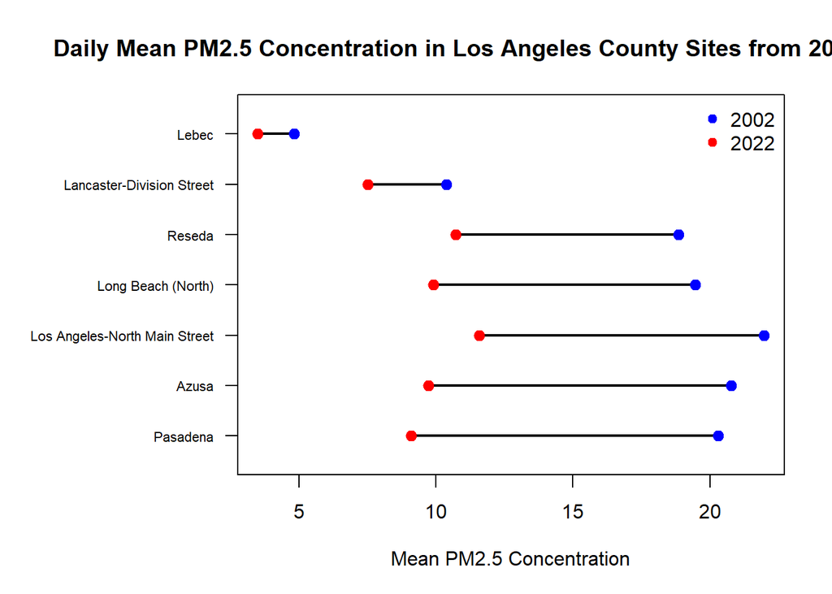

```r
Site_Means <- aggregate(PM2.5 ~ Site + Year, data = LA_Data, FUN = mean)

Sites_2002 <- Site_Means[Site_Means$Year == 2002, c("Site", "PM2.5")]

Sites_2022 <- Site_Means[Site_Means$Year == 2022, c("Site", "PM2.5")]

names(Sites_2002)[2] <- "Mean_2002"
names(Sites_2022)[2] <- "Mean_2022"

Site_Comparison <- merge(Sites_2002, Sites_2022,by = "Site")

Site_Comparison$Change <- Site_Comparison$Mean_2022 - Site_Comparison$Mean_2002

Site_Comparison <- Site_Comparison[order(Site_Comparison$Change),]

positions <- seq_len(nrow(Site_Comparison))

par(mar = c(5, 10, 4, 2))

plot(NA, xlim = range(Site_Comparison$Mean_2002, Site_Comparison$Mean_2022), ylim = c(0.5, nrow(Site_Comparison) + 0.5), yaxt = "n", xlab = "Mean PM2.5 Concentration", ylab = "", main = "Daily Mean PM2.5 Concentration in Los Angeles County Sites from 2002 and 2022")

axis(side = 2, at = positions, labels = Site_Comparison$Site, las = 1, cex.axis = 0.7)

segments(x0 = Site_Comparison$Mean_2002, y0 = positions, x1 = Site_Comparison$Mean_2022, y1 = positions, lwd = 2)

points(Site_Comparison$Mean_2002, positions, pch = 19, col = "blue", cex = 1.2)

points(Site_Comparison$Mean_2022, positions, pch = 19, col = "red", cex = 1.2)

legend("topright", legend = c("2002", "2022"), col = c("blue", "red"), pch = 19, bty = "n")
```

## Summary

Based on the dumbbell plot, mean daily PM2.5 concentrations decreased in all seven Los Angeles county cities that recorded in both 2002 and 2022. Lebec and Lancaster-Division Street had the smallest reductions, while Reseda, Long Beach (North), Los Angeles-North Main Street, Azusa, and Pasadena had considerable reductions. It should be noted that not all Los Angeles County cities are represented, as some locations were missing data from 2002 or 2022, making it impossible to compare mean PM2.5 concentrations between the years.